# PRSs after CABG & PCI

**Libraries**

```r
#setwd("/finngen/red/cabg_prs")

#install.packages("/home/ivm/R/src/packrat_0.5.0.tar.gz", repos=NULL, type="source")

packrat::on()
library(tidyverse)
library(survival)   # survival analysis

library(data.table) # fread() function
library(gridExtra)  # plots to grid
library(survminer)  # ggbased visualization and extra diagnostics
library(survRM2)    # restricted mean survival times
library(visdat)     # visualization of tibble and na's
library(forestplot) # forestplot
library(compareC)   # compare c-index
library(kableExtra) # Pretty tables
library(tableone)   # Characteristics table

source('/finngen/red/cabg_prs/scripts/functions2.R')

data_path <- "/finngen/red/cabg_prs/data"
prs_path <- "/finngen/red/cabg_prs/data/ukb_prs"
fig_path <- "/finngen/red/cabg_prs/figs"
```

# 1 Data

## 1.1 Variables

**Main endpoints**

- I9_CABG, Coronary artery bypass crafting
- I9_ANGIO, Coronary angiopasty
- I9_REVASC, I9_CABG OR I9_ANGIO

Three samples: patients *after* CABG, ANGIO and REVASC.

**For polygenic riskscores**

- I9_AF (ukb: 20002_1471), Atrial fibrillation
- I9_CHD, Major coronary heart disease event
- I9_INTRACRA, Nontraumatic intracranial haemmorrhage
- I9_MI, Myocardial infarction
- I9_STR, Stroke, excluding SAH
- K11_GIBLEEDING, GI-bleeding

**For clinical riskscore CHADSVASc:** * Congestive heart failure = I9_HEARTFAIL * Hypertension = I9_HYPTENS * Diabetes mellitus = E4_DIABETES * Stroke, TIA, or TE = C_STROKE * Vascular disease = I9_MI or I9_PAD

## 1.2 Download & preprocess data

**Copying and preprocessing outside R** Endpoint and covariate files transfered and unzipped. Columns selected from endpoint file prior to import to r, because the original phenotype file is very large.

```bash
#Endpoint file and covariate files unzipped
phenodir="/finngen/red/cabg_prs/data/phenotypes"
gzip -dc /finngen/library-red/finngen_R6/phenotype_2.0/data/finngen_R6_v2_endpoint.gz > $phenodir/finngen_R6_v2_endpoint
gzip -dc /finngen/library-red/finngen_R6/phenotype_2.0/data/finngen_R6_cov_pheno_1.0.txt.gz > $phenodir/finngen_R6_cov_pheno_1.0.txt

#Self written perl-script to extract columns from phenotype file (runned from directory 'scripts')
phenodir="/finngen/red/cabg_prs/data/phenotypes"
perl select_columns.pl $phenodir/finngen_R6_v2_endpoint       $phenodir/finngen_R6_v2_CABG    fg_pheno_cols.txt &
perl select_columns.pl $phenodir/finngen_R6_cov_pheno_1.0.txt $phenodir/R6_cov_pheno_selected fg_cov_cols.txt &
perl select_columns.pl $phenodir/finngen_R6_v2_endpoint       $phenodir/finngen_R6_v2_chadsvasc    fg_chadsvasc_cols.txt &
```

**Loading and combining the data**

Downloading the data

```r
names_in <- list("I9_AF", "I9_CHD", "I9_INTRACRA", "I9_MI", "I9_STR", "K11_GIBLEEDING")

#PRS scores
prs_df <- lapply(names_in, function(name) {
  fread(str_glue("{prs_path}/ukb.{name}.both_sexes.profile")) %>%
        select(IID, SCORE) %>%
      rename(FINNGENID = IID, !!paste(name, "SCORE", sep="_") := SCORE)}
  ) %>%
  reduce(left_join, by = "FINNGENID")


#endpoints and covariates
phenotypes <- fread(str_glue("{data_path}/phenotypes/finngen_R6_v2_CABG"), sep = "\t")
covs_in <- fread(str_glue("{data_path}/phenotypes/R6_cov_pheno_selected"), sep = "\t")
pheno_chdvsc <- fread(str_glue("{data_path}/phenotypes/finngen_R6_v2_chadsvasc"), sep = "\t") %>%
  select(-contains('MI')) #To avoid duplicates
```

Combining the data

```r
df <- phenotypes %>%
  left_join(prs_df, by = "FINNGENID") %>%
  left_join(covs_in, by = "FINNGENID") %>%
  left_join(pheno_chdvsc, by = "FINNGENID") %>%
  as_tibble() %>%
  mutate_at(c("batch","cohort"),as.factor)
```

**Preprocess**

Removing individuals without genetic information Also endpointnames are simplified.

```r
#
#glimpse(df)
#vis_dat(sample_n(df, 10000))
df <- df %>% filter(!is.na(batch)) %>%
  rename_at(vars(contains('I9_')), list(~str_remove(., "I9_"))) %>%
  rename_at(vars(contains('K11_')), list(~str_remove(., "K11_"))) %>%
  rename_at(vars(contains('E4_')), list(~str_remove(., "E4_"))) %>%
  rename_at(vars(contains('C_STRO')), list(~str_remove(., "C_"))) %>%
  rename_at(vars(contains('ANGIO')), list(~str_replace(., "ANGIO", "PCI")))
#vis_dat(sample_n(df, 10000))

#Number of individuals:
#dim(df)[1]
```

Creating scaled & categorical variables

```r
#my_probs = c(0 ,0.2, 0.8, 1)
#my_labels =  c(">20%","20-80%",">80")

#my_probs = c(0 , 0.1, 0.2, 0.8, 0.9, 1)
#my_labels =  c(">10%", "10-20%", "20-80%", "80-90%", ">90%")

my_probs = c(0,0.025,0.2,0.8,0.975,1)
my_labels =  c("<2.5%","2.5-20%","20-80%","80-97.5%",">97.5%")

df <- df %>%
  mutate_at(vars(contains('SCORE')), list(SCALED = ~scale(.)[,1])) %>%
  rename_at(vars(contains('SCALED')), list(~str_remove(., "SCORE_"))) %>%
  mutate_at(vars(contains('SCORE')),
            list(CAT = ~cut(., breaks=quantile(., probs = my_probs),
                            labels=my_labels, include.lowest = T))) %>%
  rename_at(vars(contains('CAT')), list(~str_remove(., "SCORE_")))

#test <- df[1:20, 20:40]
```

## 1.3 Properties of variables

Redefined name variables:

```r
names_oper <- list("REVASC", "CABG", "PCI")
names_ep <- list("AF", "INTRACRA", "MI", "STR", "GIBLEEDING")
```

**Sex and age**

```r
#Sex and age
df %>%
  summarise(N=n(),N_fem = sum(SEX_IMPUTED), fem_perc = mean(SEX_IMPUTED)*100, end_age = mean(FU_END_AGE), end_age_sd = sd(FU_END_AGE)) %>%
  knitr::kable() %>% kable_styling()
```

| N | N_fem | fem_perc | end_age | end_age_sd |
| --- | --- | --- | --- | --- |
| 260405 | 147061 | 56.47395 | 59.4868 | 17.63698 |

## 1.4 Subset the data by operations

**Create datasets for each operations**

Lists with three datasets for each operations created

```r
#Datasets for each operation are filtered.
#As FinnGen assignes NA's to similar endpoints, we must replace NA's for
#AF and MI by zero, or they do not have observations.

dfs.oper <- lapply(names_oper, function(name){
    df %>% filter(get(name) == 1) %>%
    mutate(AF = if_else(is.na(AF), as.integer(0), AF),
           MI = if_else(is.na(MI), as.integer(0), MI))
  }) %>% setNames(names_oper)
```

Sex and age

```r
#Sex and age

names_oper_age <- lapply(names_oper, function(name) {str_glue("{name}_AGE")})

mapply(
  function(dfi, name){
    dfi %>% summarise(N=n(), N_fem = sum(SEX_IMPUTED), fem_perc = mean(SEX_IMPUTED)*100,
            mean_oper_age = mean(get(name)), sd_oper_age = sd(get(name)))},
  dfs.oper, names_oper_age) %>%
  as.matrix() %>% t() %>% as.data.frame() %>%
  mutate_at(.vars= c("fem_perc","mean_oper_age","sd_oper_age"), as.numeric) %>%
  knitr::kable(digits=2) %>%
  kable_styling()
```

|  | N | N_fem | fem_perc | mean_oper_age | sd_oper_age |
| --- | --- | --- | --- | --- | --- |
| REVASC | 14741 | 3541 | 24.02 | 64.09 | 10.33 |
| CABG | 6904 | 1245 | 18.03 | 63.78 | 9.69 |
| PCI | 9519 | 2612 | 27.44 | 64.72 | 10.64 |

## 1.5 Subset data by operations and events

**Datasets for each combination of operation and PRS**

For each endpoint, *remove the prevalent cases* and create list of new datasets. Both list of dataframes and long format dataframes are created for each operation.

```r
#Datasets for each operation are filtered and added to list

covs <- c("SEX_IMPUTED", "batch", "BL_YEAR","PC1", "PC2", "PC3", "PC4", "PC5", "PC6", "PC7", "PC8","PC9", "PC10")

#Lists of dataframes for each operations.
#PREVALENT ARE REMOVED

dfs <- lapply(names_oper, function(oper){
  my_create_sub_dfs(oper, dfs.oper, names_ep, covs)}) %>%
  setNames(names_oper)
```

## 1.6 Characteristics tables for each operations

```r
catVars <-  c("SEX_IMPUTED")
chr_rownames <- c("Age, years (SD)", "Women, n (%)")

chars <-
  lapply(names_oper, function(oper){
    lapply(names_ep, function(ep){
      my_char_table(dfs[[oper]][[ep]], strata=unlist(ep), myVars=c(str_glue("{ep}_AGE"), "SEX_IMPUTED"), catVars, chr_rownames, name="N") %>%
        rbind(Endpoint=c("","",""), .) %>%
        set_rownames(., c(ep, "N", chr_rownames)) %>%
        set_colnames(., c("Overall", "Cases", "Controls"))
    }) %>% setNames(names_ep)
  }) %>% setNames(names_oper)

#REVASC
do.call(rbind, chars$REVASC) %>%
  knitr::kable() %>% kable_styling()
```

|  | Overall | Cases | Controls |
| --- | --- | --- | --- |
| AF |  |  |  |
| N | 13082 | 3556 | 9526 |
| Age, years (SD) | 73.30 (9.57) | 72.51 (9.29) | 73.60 (9.66) |
| Women, n (%) | 3169 (24.2) | 777 (21.9) | 2392 (25.1) |
| INTRACRA |  |  |  |
| N | 14568 | 237 | 11693 |
| Age, years (SD) | 75.10 (9.41) | 73.04 (9.99) | 74.60 (9.50) |
| Women, n (%) | 3501 (24.0) | 58 (24.5) | 2849 (24.4) |
| MI |  |  |  |
| N | 7823 | 1322 | 6501 |
| Age, years (SD) | 74.66 (9.35) | 70.85 (10.05) | 75.44 (9.01) |
| Women, n (%) | 1993 (25.5) | 316 (23.9) | 1677 (25.8) |
| STR |  |  |  |
| N | 13902 | 1479 | 11468 |
| Age, years (SD) | 74.44 (9.55) | 71.81 (9.96) | 74.50 (9.49) |
| Women, n (%) | 3337 (24.0) | 312 (21.1) | 2756 (24.0) |
| GIBLEEDING |  |  |  |
| N | 14468 | 607 | 13652 |
| Age, years (SD) | 74.95 (9.43) | 71.99 (10.14) | 75.10 (9.37) |
| Women, n (%) | 3479 (24.0) | 132 (21.7) | 3272 (24.0) |

```r
#CABG
do.call(rbind, chars$CABG) %>%
  knitr::kable() %>% kable_styling()
```

|  | Overall | Cases | Controls |
| --- | --- | --- | --- |
| AF |  |  |  |
| N | 6132 | 2127 | 4005 |
| Age, years (SD) | 74.07 (8.88) | 72.51 (8.98) | 74.90 (8.71) |
| Women, n (%) | 1118 (18.2) | 377 (17.7) | 741 (18.5) |
| INTRACRA |  |  |  |
| N | 6829 | 144 | 5225 |
| Age, years (SD) | 76.27 (8.48) | 74.27 (9.45) | 75.86 (8.56) |
| Women, n (%) | 1235 (18.1) | 32 (22.2) | 958 (18.3) |
| MI |  |  |  |
| N | 4141 | 746 | 3395 |
| Age, years (SD) | 75.46 (8.78) | 71.47 (9.67) | 76.34 (8.32) |
| Women, n (%) | 813 (19.6) | 148 (19.8) | 665 (19.6) |
| STR |  |  |  |
| N | 6513 | 881 | 5146 |
| Age, years (SD) | 75.48 (8.74) | 71.96 (9.45) | 75.77 (8.53) |
| Women, n (%) | 1186 (18.2) | 148 (16.8) | 935 (18.2) |
| GIBLEEDING |  |  |  |
| N | 6793 | 326 | 6387 |
| Age, years (SD) | 76.08 (8.56) | 72.51 (9.55) | 76.27 (8.46) |
| Women, n (%) | 1227 (18.1) | 56 (17.2) | 1154 (18.1) |

```r
#PCI
do.call(rbind, chars$PCI) %>%
  knitr::kable() %>% kable_styling()
```

|  | Overall | Cases | Controls |
| --- | --- | --- | --- |
| AF |  |  |  |
| N | 8296 | 1854 | 6442 |
| Age, years (SD) | 72.79 (9.89) | 72.48 (9.44) | 72.88 (10.01) |
| Women, n (%) | 2312 (27.9) | 477 (25.7) | 1835 (28.5) |
| INTRACRA |  |  |  |
| N | 9402 | 123 | 7742 |
| Age, years (SD) | 74.36 (9.78) | 72.01 (10.11) | 73.88 (9.84) |
| Women, n (%) | 2579 (27.4) | 35 (28.5) | 2133 (27.6) |
| MI |  |  |  |
| N | 4373 | 715 | 3658 |
| Age, years (SD) | 73.98 (9.67) | 70.42 (10.19) | 74.68 (9.41) |
| Women, n (%) | 1327 (30.3) | 202 (28.3) | 1125 (30.8) |
| STR |  |  |  |
| N | 8931 | 757 | 7561 |
| Age, years (SD) | 73.81 (9.89) | 71.62 (10.54) | 73.79 (9.84) |
| Women, n (%) | 2450 (27.4) | 195 (25.8) | 2054 (27.2) |
| GIBLEEDING |  |  |  |
| N | 9314 | 349 | 8812 |
| Age, years (SD) | 74.23 (9.79) | 71.38 (10.52) | 74.36 (9.74) |
| Women, n (%) | 2563 (27.5) | 87 (24.9) | 2414 (27.4) |

# 2 Survival analysis

- Take patients after the operation.
- Remove prevalent cases of the endpoint
- Survival analysis:
  - Hazard ratios per 1 SD change: table & curves
- Covariates: SEX_IMPUTED, batch, BL_YEAR, PC1:PC10

## 2.1 Proportional hazard assumption: log log curve

**log log curve**

**Model by survfit**

```r
kms <-
  lapply(names_oper, function(oper){
    lapply(names_ep, function(ep){
      survfit(Surv(AGE_DIFF, get(ep)) ~ get(str_glue("{ep}_CAT")), data=dfs[[oper]][[ep]])
    }) %>% setNames(names_ep)
  }) %>% setNames(names_oper)
```

**KM plots**

```r
for(oper in unlist(names_oper)) {
  ep=names_ep[[1]]   #Tämän alustuksen tarve on kyllä ihme juttu. Suoritus kaatuu ilman sitä.

  plot_list <- lapply(names_ep, function(ep){
    print(str_glue("{oper}-{ep}"))
    my_ggkmplot(kms[[oper]][[ep]], str_glue("{oper}-{ep}"), my_labels, isFive=T)
  })
  plots <- arrange_ggsurvplots(plot_list, nrow = 2, ncol = 3, title = "Kaplan Meier curves")
  ggsave(file = str_glue("{fig_path}/km.prs.after.{oper}.png"), plot = plots, height = 6, width = 12, dpi = 200)
}
```

[output not shown]

**log log curve**

```
## REVASC-AF
## REVASC-INTRACRA
## REVASC-MI
## REVASC-STR
## REVASC-GIBLEEDING
```

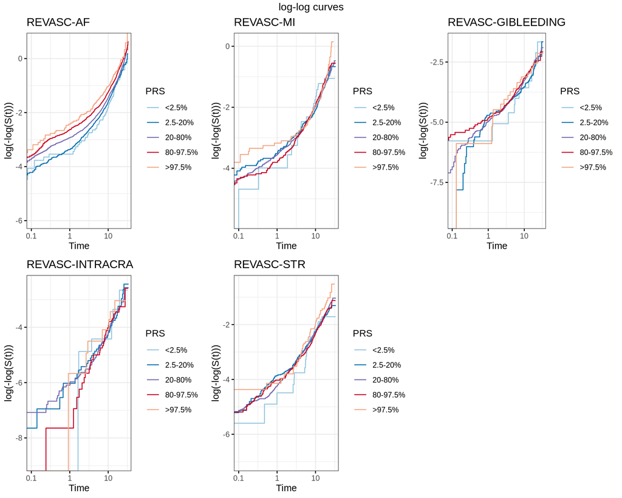

```
## CABG-AF
## CABG-INTRACRA
## CABG-MI
## CABG-STR
## CABG-GIBLEEDING
```

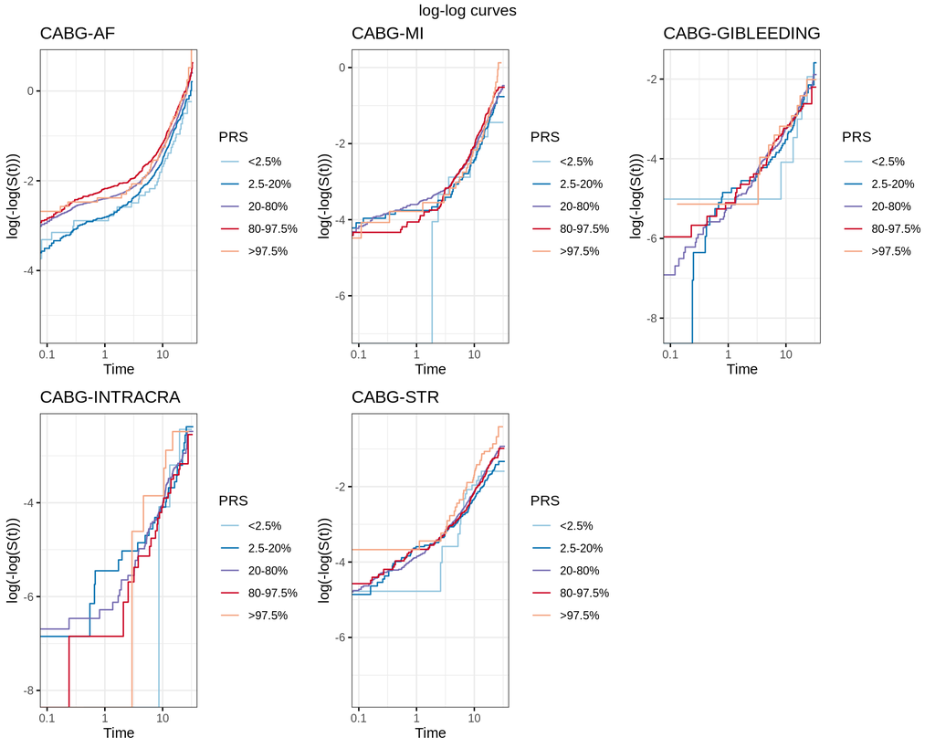

```
## PCI-AF
## PCI-INTRACRA
## PCI-MI
## PCI-STR
## PCI-GIBLEEDING
```

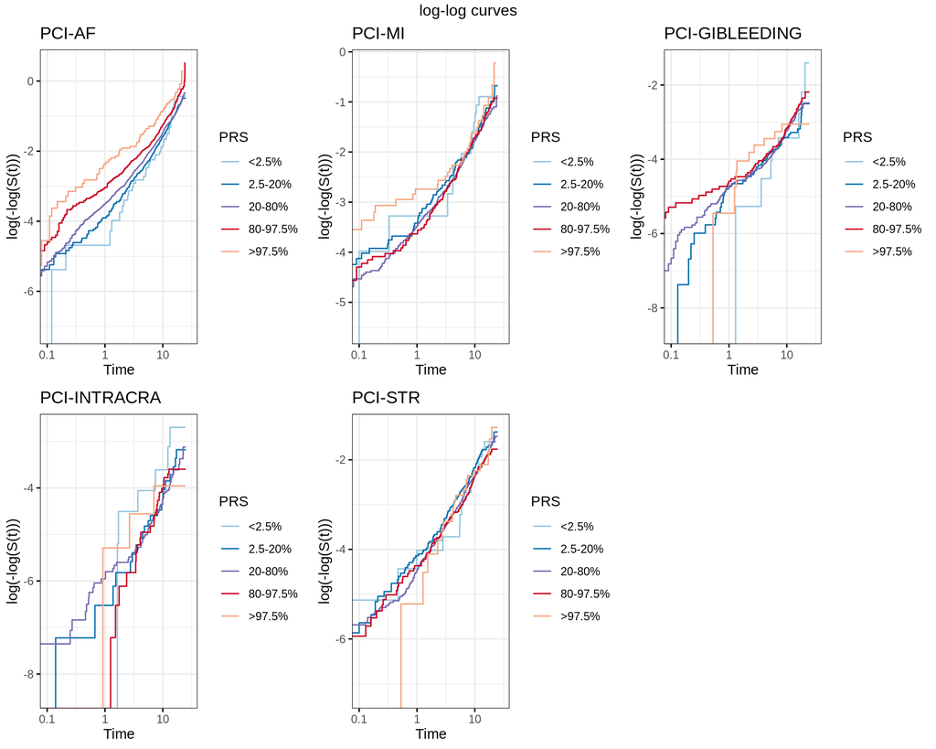

```r
for(oper in unlist(names_oper)) {
  ep=names_ep[[1]]   #Tämän alustuksen tarve on kyllä ihme juttu. Suoritus kaatuu ilman sitä.

  plot_list <- lapply(names_ep, function(ep){
    print(str_glue("{oper}-{ep}"))
    my_ggkmplot(kms[[oper]][[ep]], str_glue("{oper}-{ep}"), my_labels, fun="cloglog", xlim=c(0.1,30), isFive=T)

  })
  plots <- arrange_ggsurvplots(plot_list, nrow = 2, ncol = 3, title = "log-log curves")
  ggsave(file = str_glue("{fig_path}/log.prs.after.{oper}.png"), plot = plots, height = 6, width = 12, dpi = 200)
}
```

Not very convincing. AF seems OK. Perhaps also others roughly parallel, but not really different.

## 2.2 Cox model: covariate adjusted, continuous score

**Running models**

```r
covs_f<- paste(covs, collapse = " + ")

cxs.cs <-
  lapply(names_oper, function(oper){
    lapply(names_ep, function(ep){
      my_formula <- str_glue("Surv(AGE_DIFF, {ep}) ~ {ep}_SCALED + {oper}_AGE + {covs_f}")
      coxph(as.formula(my_formula), data=dfs[[oper]][[ep]])
    }) %>% setNames(names_ep)
  }) %>% setNames(names_oper)
```

**Table: Hazard rations**

*Main results*

```r
oper="REVASC"
my_cxlist_to_hrtable(cxs.cs[[oper]], oper) %>%
    knitr::kable(digits=2) %>% kable_styling()
```

| REVASC | HR (95% CI) | P-value |
| --- | --- | --- |
| AF | 1.18 (1.14-1.22) | 5.1e-23 |
| INTRACRA | 1.02 (0.89-1.16) | 0.79 |
| MI | 1.06 (1-1.12) | 0.035 |
| STR | 1.05 (1-1.11) | 0.048 |
| GIBLEEDING | 1.08 (1-1.17) | 0.061 |

```r
oper="CABG"
my_cxlist_to_hrtable(cxs.cs[[oper]], oper) %>%
    knitr::kable(digits=2) %>% kable_styling()
```

| CABG | HR (95% CI) | P-value |
| --- | --- | --- |
| AF | 1.15 (1.1-1.2) | 1e-10 |
| INTRACRA | 1.02 (0.86-1.21) | 0.83 |
| MI | 1.13 (1.05-1.21) | 0.0017 |
| STR | 1.11 (1.04-1.19) | 0.002 |
| GIBLEEDING | 1.05 (0.94-1.17) | 0.43 |

```r
oper="PCI"
my_cxlist_to_hrtable(cxs.cs[[oper]], oper) %>%
    knitr::kable(digits=2) %>% kable_styling()
```

| PCI | HR (95% CI) | P-value |
| --- | --- | --- |
| AF | 1.22 (1.16-1.28) | 5.7e-17 |
| INTRACRA | 0.94 (0.79-1.13) | 0.51 |
| MI | 1.02 (0.95-1.1) | 0.59 |
| STR | 0.98 (0.91-1.06) | 0.62 |
| GIBLEEDING | 1.08 (0.97-1.2) | 0.17 |

After all operations, AF PRS shows significant associations to the survival time before first AF event. After bonferroni correction (0.05/15=0.003) other endpoints are not statistically significant (except CABG-STR and CABG-MI).

*Sex & age of operation included(REVASC only)*

```r
#SEX and AGE for REVASC
my_cxlist_to_hrtable_selected(cxs.cs$REVASC, "REVASC", select="SEX|AGE") %>%
  knitr::kable(digits=2) %>%
    kable_styling()
```

| REVASC | Variable | HR (95% CI) | P-value |
| --- | --- | --- | --- |
| AF | REVASC_AGE | 1.06 (1.05-1.06) | 4.6e-180 |
| AF | SEX_IMPUTED | 0.86 (0.79-0.93) | 0.00028 |
| INTRACRA | REVASC_AGE | 1.04 (1.02-1.05) | 5.6e-07 |
| INTRACRA | SEX_IMPUTED | 1.12 (0.82-1.54) | 0.47 |
| MI | REVASC_AGE | 1.02 (1.01-1.02) | 9.8e-08 |
| MI | SEX_IMPUTED | 1.03 (0.9-1.17) | 0.67 |
| STR | REVASC_AGE | 1.04 (1.03-1.04) | 1e-32 |
| STR | SEX_IMPUTED | 0.89 (0.78-1.02) | 0.086 |
| GIBLEEDING | REVASC_AGE | 1.04 (1.03-1.05) | 1.1e-15 |
| GIBLEEDING | SEX_IMPUTED | 0.92 (0.75-1.12) | 0.4 |

Operation age is significant in all cases. Sex is significant only in case of AF.

**All coefficients**

```r
lapply(cxs.cs, print)
```

```
## $AF
## Call:
## coxph(formula = as.formula(my_formula), data = dfs[[oper]][[ep]])
##
##                                                        coef  exp(coef)
## AF_SCALED                                         1.670e-01  1.182e+00
## REVASC_AGE                                        5.680e-02  1.058e+00
## SEX_IMPUTED                                      -1.533e-01  8.578e-01
## batchAxiomGT1_b02_V2P2.calls                      1.398e-01  1.150e+00
## batchAxiomGT1_b03_V2P2.calls                      1.587e-01  1.172e+00
## batchAxiomGT1_b04_V2P2.calls                      3.121e-01  1.366e+00
## batchAxiomGT1_b05_V2P2.calls                      2.779e-01  1.320e+00
## batchAxiomGT1_b06_V2P2.calls                      1.651e-01  1.180e+00
## batchAxiomGT1_b07_V2P2.calls                      3.462e-01  1.414e+00
## batchAxiomGT1_b08_V2P2.calls                      2.896e-01  1.336e+00
## batchAxiomGT1_b09_V2P2.calls                      2.894e-01  1.336e+00
## batchAxiomGT1_b10_V2P2.calls                      4.391e-01  1.551e+00
## batchAxiomGT1_b11_V2P2.calls                      2.758e-01  1.318e+00
## batchAxiomGT1_b12_V2P2.calls                      2.294e-01  1.258e+00
## batchAxiomGT1_b13_V2P2.calls                      6.973e-01  2.008e+00
## batchAxiomGT1_b14_V2P2.calls                      3.538e-01  1.425e+00
## batchAxiomGT1_b15_V2P2.calls                      6.574e-01  1.930e+00
## batchAxiomGT1_b16_V2P2.calls                      3.658e-01  1.442e+00
## batchAxiomGT1_b17_V2P2.calls                      1.619e-01  1.176e+00
## batchAxiomGT1_b18_V2P2.calls                      3.078e-01  1.360e+00
## batchAxiomGT1_b19_V2P2.calls                      3.438e-01  1.410e+00
## batchAxiomGT1_b20_V2P2.calls                      4.240e-01  1.528e+00
## batchAxiomGT1_b21_V2P2.calls                      5.096e-01  1.665e+00
## batchAxiomGT1_b22_V2P2.calls                      6.283e-01  1.874e+00
## batchAxiomGT1_b23_V2P2.calls                      3.916e-01  1.479e+00
## batchAxiomGT1_b24_V2P2.calls                      2.465e-01  1.280e+00
## batchAxiomGT1_b25_V2P2.calls                      4.714e-01  1.602e+00
## batchAxiomGT1_b26_V2P2.calls                      2.805e-01  1.324e+00
## batchAxiomGT1_b27_V2P2.calls                      2.388e-01  1.270e+00
## batchAxiomGT1_b28_V2P2.calls                      1.265e-01  1.135e+00
## batchAxiomGT1_b29_V2P2.calls                      4.490e-01  1.567e+00
## batchAxiomGT1_b30_V2P2.calls                      5.239e-01  1.689e+00
## batchAxiomGT1_b31_V2.calls                        3.878e-01  1.474e+00
## batchAxiomGT1_b3234_V2.calls                      3.419e-01  1.408e+00
## batchAxiomGT1_b33_V2.calls                        3.082e-01  1.361e+00
```

[output cut: 2743 more lines]

```
## BL_YEAR                                           1.296e-02  0.323    0.747
## PC1                                               2.721e+00  0.648    0.517
## PC2                                               5.111e+00 -0.728    0.466
## PC3                                               5.650e+00  1.280    0.201
## PC4                                               6.488e+00 -1.066    0.286
## PC5                                               7.079e+00  0.744    0.457
## PC6                                               7.139e+00 -0.728    0.467
## PC7                                               8.124e+00 -0.374    0.709
## PC8                                               8.583e+00  1.449    0.147
## PC9                                               9.037e+00  0.421    0.673
## PC10                                              9.465e+00  1.160    0.246
##
## Likelihood ratio test=132.8  on 88 df, p=0.001449
## n= 9161, number of events= 349
##    (153 observations deleted due to missingness)
```

[output not shown]

[output cut: 2748 more lines]

[output not shown]

Genetic covariates are not significant. Only very few exceptions.

**Cox-plot**

Creating covariate combinations for the plot.

```r
var_qs= c(0.01, 0.1, 0.5, 0.9, 0.99)  #Vastaa suunnilleen niitä meidän kategorioita...
#var_qs=c(0.1, 0.2, 0.5, 0.8, 0.9)

exp.cs.cxs <-
  lapply(names_oper, function(oper){
    lapply(names_ep, function(ep){
      ep_scaled <- str_glue("{ep}_SCALED")
      my_expand_cs(cxs.cs[[oper]][[ep]], ep_scaled, dfs[[oper]][[ep]],
                   batch = "AxiomGT1_b44_V2.calls", agename=str_glue("{oper}_AGE"),
                   var_qs = quantile(dfs[[oper]][[ep]][[ep_scaled]], var_qs))
    }) %>% setNames(names_ep)
  }) %>% setNames(names_oper)


fit.cs.cxs <-
  lapply(names_oper, function(oper){
    lapply(names_ep, function(ep){
        survfit(cxs.cs[[oper]][[ep]], newdata = exp.cs.cxs[[oper]][[ep]])
  }) %>% setNames(names_ep)
}) %>% setNames(names_oper)
```

And the plot:

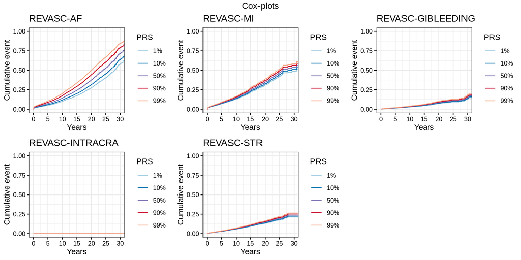

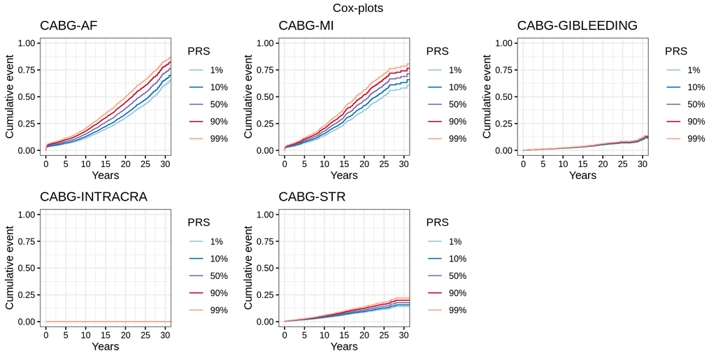

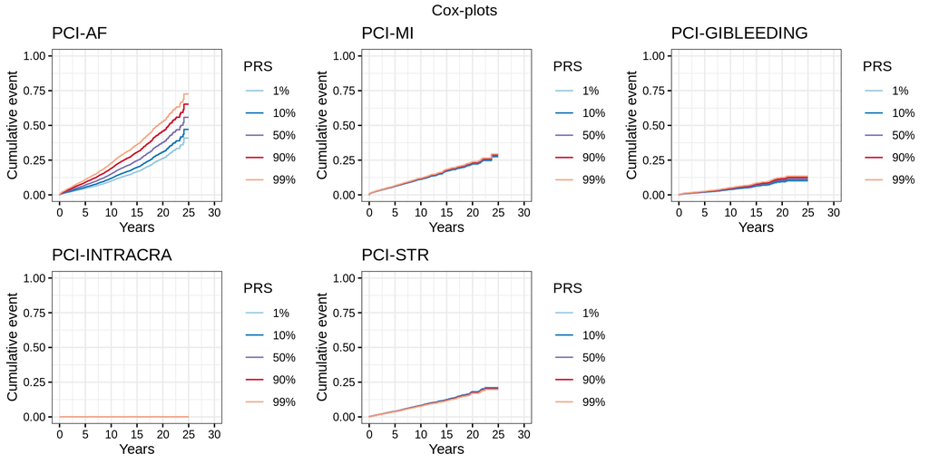

```r
my_labels = c("1%", "10%", "50%", "90%", "99%")

for(oper in unlist(names_oper)) {
  ep=names_ep[[1]]   #Tämän alustuksen tarve on kyllä ihme juttu. Suoritus kaatuu ilman sitä.

  plot_list <- lapply(names_ep, function(ep){
    #print(str_glue("{oper}-{ep}"))
    my_ggcoxplot(fit.cs.cxs[[oper]][[ep]], exp.cs.cxs[[oper]][[ep]], str_glue("{oper}-{ep}"), my_labels, xlim=c(0,30), isFive=T)
  })
  plots <- arrange_ggsurvplots(plot_list, nrow = 2, ncol = 3, title = "Cox-plots")
  ggsave(file = str_glue("{fig_path}/cx.cs.prs.after.{oper}.png"), plot = plots, height = 6, width = 12, dpi = 200)
}
```

**Proportional hazard assumption**

Schoenfeld residuals against the transformed time

```r
extract_ph_test <- function(cx){
  tmp <- cox.zph(cx)
  tmp$table[c(1,16),]
}

lapply(names_oper, function(oper){
  lapply(names_ep, function(ep){
    tryCatch(extract_ph_test(cxs.cs[[oper]][[ep]]), error=function(e) NULL)
  }) %>% setNames(names_ep)
}) %>% setNames(names_oper)
```

```
## $REVASC
## $REVASC$AF
##               chisq df         p
## AF_SCALED  1.468696  1 0.2255516
## GLOBAL    64.292672 88 0.9730194
##
## $REVASC$INTRACRA
## NULL
##
## $REVASC$MI
##                chisq df           p
## MI_SCALED   7.914835  1 0.004903104
## GLOBAL    115.428845 87 0.022410163
##
## $REVASC$STR
##                chisq df          p
## STR_SCALED  4.232192  1 0.03966418
## GLOBAL     80.096572 88 0.71359233
##
## $REVASC$GIBLEEDING
## NULL
##
##
## $CABG
## $CABG$AF
##                chisq df         p
## AF_SCALED  0.2455848  1 0.6202013
## GLOBAL    78.0287996 87 0.7434383
##
## $CABG$INTRACRA
## NULL
##
## $CABG$MI
## NULL
##
## $CABG$STR
## NULL
##
## $CABG$GIBLEEDING
## NULL
##
##
## $PCI
## $PCI$AF
##                chisq df         p
## AF_SCALED  0.5910695  1 0.4420059
## GLOBAL    95.5386300 88 0.2733491
##
## $PCI$INTRACRA
## NULL
##
## $PCI$MI
##                chisq df         p
## MI_SCALED  0.3771847  1 0.5391138
## GLOBAL    95.1349056 87 0.2582809
##
## $PCI$STR
## NULL
##
## $PCI$GIBLEEDING
## NULL
```

```r
lapply(names_ep, function(ep){
    tryCatch(cox.zph(cxs.cs[["REVASC"]][[ep]]), error=function(e) NULL)
}) %>% setNames(names_ep)
```

```
## $AF
##                chisq df       p
## AF_SCALED    1.46870  1 0.22555
## REVASC_AGE   0.07807  1 0.77993
## SEX_IMPUTED 11.96613  1 0.00054
## batch       43.69952 74 0.99807
## BL_YEAR      1.09650  1 0.29503
## PC1          1.96010  1 0.16150
## PC2          0.07845  1 0.77941
## PC3          1.78039  1 0.18210
## PC4          0.07830  1 0.77962
## PC5          0.12467  1 0.72402
## PC6          2.00501  1 0.15678
## PC7          0.00512  1 0.94296
## PC8          0.46072  1 0.49729
## PC9          0.72146  1 0.39567
## PC10         0.28044  1 0.59642
## GLOBAL      64.29267 88 0.97302
##
## $INTRACRA
## NULL
##
## $MI
##                chisq df      p
## MI_SCALED   7.91e+00  1 0.0049
## REVASC_AGE  1.98e+00  1 0.1599
## SEX_IMPUTED 2.28e-01  1 0.6329
## batch       9.26e+01 73 0.0605
## BL_YEAR     1.57e+00  1 0.2098
## PC1         1.44e+00  1 0.2307
## PC2         1.37e-01  1 0.7112
## PC3         1.70e+00  1 0.1918
## PC4         1.17e-01  1 0.7319
## PC5         9.71e-02  1 0.7554
## PC6         2.06e+00  1 0.1507
## PC7         8.98e-03  1 0.9245
## PC8         2.37e+00  1 0.1240
## PC9         9.03e-01  1 0.3420
## PC10        8.00e-03  1 0.9287
## GLOBAL      1.15e+02 87 0.0224
##
## $STR
##                chisq df     p
## STR_SCALED   4.23219  1 0.040
## REVASC_AGE   0.01142  1 0.915
## SEX_IMPUTED  0.81062  1 0.368
## batch       66.12723 74 0.731
## BL_YEAR      0.00353  1 0.953
## PC1          0.20723  1 0.649
## PC2          0.66322  1 0.415
## PC3          1.18484  1 0.276
## PC4          0.43544  1 0.509
## PC5          2.80681  1 0.094
## PC6          1.50981  1 0.219
## PC7          0.47578  1 0.490
## PC8          0.96600  1 0.326
## PC9          1.28026  1 0.258
## PC10         0.18277  1 0.669
## GLOBAL      80.09657 88 0.714
##
## $GIBLEEDING
## NULL
```